# Алгоритмы кластеризации

Основная задача этого задания - реализация одного из алгоритмов кластеризации. Кроме того, необходимо будет проверить корректность работы алгоритма на тестовых данных, проверить работу алгоритма на данных различной природы, подбирать параметры алгоритма.

```python
import random
import pandas as pd
import pylab as pl
import numpy as np
import scipy.spatial as ss
import sklearn.cluster as sc
import sklearn.manifold as sm
import sklearn.datasets as ds
import sklearn.metrics as smt

import matplotlib.pyplot as plt
%matplotlib inline
plt.rcParams['figure.figsize'] = (12, 8)
```

## Реализация алгоритма

Необходимо выбрать и реализовать самостоятельно один из следующих алгоритмов кластеризации:

- Агломеративная иерархическая кластеризация с поддержкой single-linkage, complete-linkage, average-linkage (параметры - k, linkage)
- DBSCAN. (параметры - epsilon, min_pts) - нужно самостоятельно разобрать и применить критерий качества для DBSCAN
- OPTICS(*). (параметры - epsilon, min_pts)
- Gaussian Mixture Model(**) с использованием maximum a-posteriori для выбора кластера (параметр - k)

(*) - алгоритм не был разобран на занятии. Выбирайте этот пункт только если уверенно умеете программировать и хотите разобраться с более сложной идеей, чем DBSCAN  
(**) - алгоритм не был разобран на занятии, задание повышенной сложности. Выбирайте этот пункт только если хотите разобраться со сложным математическим обоснованием и точно уверены, что сможете запрограммировать и отладить.

## Интерфейс

Алгоритм кластеризации должен удовлетворять следующему интерфейсу. Конструктор принимает набор параметров, необходимых для работы алгоритма кластеризации. Метод `fit` подсчитывает параметры модели и возвращает `self`. Метод `predict` возвращает вектор с индексами кластеров для поданных в него объектов `x`

```python
from sklearn.base import BaseEstimator, ClusterMixin
from scipy.spatial import distance
from scipy.spatial.distance import cdist

class DBScanClustering(BaseEstimator, ClusterMixin):
    """
    Implement clustering algorithm according
    """

    NOISE = -1

    def __init__(self, eps=0.5, min_pts=5, random_state=42):
        """
        Please add necessary algoritm parameters to class constructor.
        eps - радиус сферы
        min_pts - плотность внутри сферы
        visited_points - посещенные точки
        clusters - распределенные по кластерам точки
        """
        self.eps = eps
        self.min_pts = min_pts
        self.random_state = random_state

        self.visited_points = set()
        self.clusters = {self.NOISE: []}
        self.clustered_points = set()
        return

    def _dbscan(self):
        # номер текущего кластера
        C = 0

        np.random.seed(seed=self.random_state)
        # обход всех точек в случайном порядке
        for point in np.random.permutation(self.n_points):
            if point in self.visited_points:
                continue
            self.visited_points.add(point)

            neighbors = self._get_neighbors(point)
            if len(neighbors) < self.min_pts:
                self.clusters[self.NOISE].append(point)
            else:
                C += 1
                self._expand_cluster(point, neighbors, C)

    # Исследование области точки core_point и ее соседей из region
    def _expand_cluster(self, core_point, region, C):
        self._update_cluster(C, core_point)

        while len(region) > 0:
            point = region.pop()

            # исследуемая точка еще не просмотрена
            if point not in self.visited_points:
                self.visited_points.add(point)

                # расширяем область исследования
                neighbors = self._get_neighbors(point)
                # если point - корневой объект, то добавим его соседей для изучения
                if len(neighbors) >= self.min_pts:
                    region.extend(neighbors)

            # исследуемая точка еще не кластеризована
            if point not in self.clustered_points:
                self._update_cluster(C, point)

                if point in self.clusters[self.NOISE]:
                    self.clusters[self.NOISE].remove(point)

    def _get_neighbors(self, point):
        # расстояния от точки point до всех остальных точек
        point_distances = np.array(self.distances[point])
        # поиск соседей в заданной сфере
        neighbors = np.where(point_distances <= self.eps)[0].tolist()
        # исключаем саму точку point
        neighbors.remove(point)
        return neighbors

    # Добавление точки point в кластер cluster_id
    def _update_cluster(self, cluster_id, point):
        if cluster_id not in self.clusters:
            self.clusters[cluster_id] = []

        self.clusters[cluster_id].append(point)
        self.clustered_points.add(point)

    # Средние расстояния от каждой точки до m ближайших соседей
    @staticmethod
    def mean_distance_to_nearest_neighbors(X, m):
        distances = cdist(X, X)
        distances.sort()
        mean_distances = np.mean(distances[:, 1:m+1], axis=1)
        return mean_distances

    def _setup_data(self, X):
        self.X = X
        self.n_points = len(X)
        self.distances = cdist(self.X, self.X)

    def fit(self, X, y=None):
        """
        Use data matrix X to compute model parameters
        """
        self._setup_data(X)
        self._dbscan()
        return self

    def predict(self, X):
        """
        Using computed model parameters predict cluster
        for all objects from X
        """
        predicted = np.zeros(len(X))

        for cluster, points in self.clusters.items():
            predicted[points] = cluster

        return predicted

    def fit_predict(self, X, y=None):
        self.fit(X, y)
        return self.predict(X)
```

Сначала проверим реализованный алгоритм кластеризации на классическом наборе данных [Iris](http://www.wikiwand.com/en/Iris_flower_data_set). Загрузим данные (они включены в библиотеку sklearn) и посмотрим на то, как они выглядят в двух проекциях (для простоты используем 2 класса из 3).

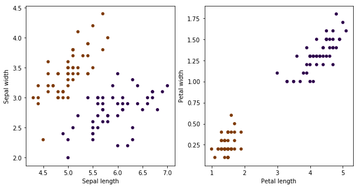

```python
iris = ds.load_iris()
x_iris = iris.data[:100]
y_iris = iris.target[:100]

pl.figure(figsize=(10, 5))

pl.subplot(1, 2, 1)
pl.scatter(x_iris[:, 0], x_iris[:, 1], c=y_iris, cmap=pl.cm.PuOr, lw=0, s=30)
plt.xlabel('Sepal length')
plt.ylabel('Sepal width')

pl.subplot(1, 2, 2)
pl.scatter(x_iris[:, 2], x_iris[:, 3], c=y_iris, cmap=pl.cm.PuOr, lw=0, s=30)
plt.xlabel('Petal length')
plt.ylabel('Petal width')
pl.show()
```

Видно, что классы разделяются, поэтому можно надеяться, что наш алгоритм "найдет" кластеры, соответствующие исходным классам. Результат работы реализованного алгоритма кластеризации предлагается сравнить с эталонной кластеризацией. Для этого предлагается изучить метрику ([adjusted rand score](http://scikit-learn.org/stable/modules/generated/sklearn.metrics.adjusted_rand_score.html)). В случае если значение этой метрики сильно отличается от 1, предлагается поработать над улучшением реализации своего алгоритма.

Посмотрим на результаты реализованного алгоритма со значениями по умолчанию: eps=0.5, min_pts=5

```python
model = DBScanClustering()
predicted_clusters = model.fit_predict(x_iris)
print(predicted_clusters)
```

```
[ 2.  2.  2.  2.  2.  2.  2.  2.  2.  2.  2.  2.  2.  2.  2.  2.  2.  2.
  2.  2.  2.  2.  2.  2.  2.  2.  2.  2.  2.  2.  2.  2.  2.  2.  2.  2.
  2.  2.  2.  2.  2. -1.  2.  2.  2.  2.  2.  2.  2.  2.  1.  1.  1.  1.
  1.  1.  1. -1.  1.  1. -1.  1.  1.  1.  1.  1.  1.  1. -1.  1.  1.  1.
  1.  1.  1.  1.  1.  1.  1.  1.  1.  1.  1.  1.  1.  1.  1. -1.  1.  1.
  1.  1.  1. -1.  1.  1.  1.  1. -1.  1.]
```

```python
print("Adjusted Rand index for iris is: %.4f" % smt.adjusted_rand_score(y_iris, predicted_clusters))
```

```
Adjusted Rand index for iris is: 0.8709
```

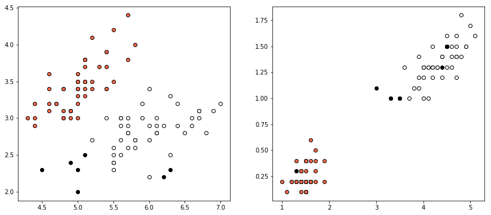

```python
fig, axes = plt.subplots(nrows=1, ncols=2, figsize=(14, 6))

unique_labels = set(predicted_clusters)
colors = [plt.cm.Reds(each) for each in np.linspace(0, 1, len(unique_labels))]

for label, color in zip(unique_labels, colors):
    # Black used for noise
    if label == -1:
        color = [0, 0, 0, 1]

    class_member_mask = (predicted_clusters == label)

    xy = x_iris[class_member_mask]
    axes[0].plot(xy[:, 0], xy[:, 1], 'o', markerfacecolor=tuple(color), markeredgecolor='k', markersize=6)
    axes[1].plot(xy[:, 2], xy[:, 3], 'o', markerfacecolor=tuple(color), markeredgecolor='k', markersize=6)
```

Видим, что результат в целом неплохой, некоторые точки на второй картинке были кластеризованы как шум, хотя они находятся в плотном скоплении. Это можно исправить, если увеличить радиус сферы eps.

Подобрать параметры модели с использованием эвристик и критериев качества.

Критерий локтя:

- Инерция (сумма квадратов расстояний от каждой из точек до ближайшего к этой точке центроида)
- Средний диаметр (максимальное расстояние между точками в кластере) или радиус (расстояние от центроида до самой дальней от него точки в кластере)
- Sihouette

Для DBSCAN применяется эвристика по подсчету среднего расстояния до min-pts точек, их сортировки, далее применяется критерий локтя (описание https://habrahabr.ru/post/322034/ или http://www.aaai.org/Papers/KDD/1996/KDD96-037.pdf)

Применим критерий для выбора параметров алгоритма. Предлагается изменить следующий код таким образом, чтобы кластеризация вызывалась с верным набором параметров, а так же при необходимости изменить этот код (для DBSCAN). На графике можно будет увидеть зависимость критерия от параметров алгоритма. Необходимо выбрать оптимальные значения этих параметров. Возможно, необходимо построить такую визуализацию несколько раз.

Воспользуемся эвристикой для выбора расстояния eps у алгоритма DBSCAN (описание https://habrahabr.ru/post/322034/). Будем менять количество точек min_pts от 3-х до 9-ти и строить график среднего расстояния от каждой точки до ближайших соседей. Далее возьмем значение eps из полосы, где происходит самый сильный перегиб.

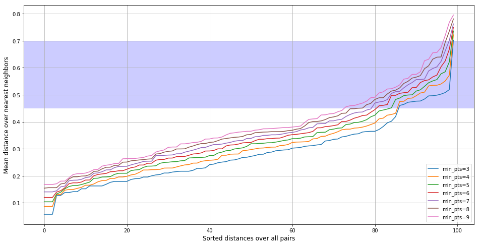

```python
fix, ax = plt.subplots(figsize=(16, 8))

for min_pts in np.arange(3, 10):
    mean_distances = DBScanClustering.mean_distance_to_nearest_neighbors(x_iris, min_pts)
    mean_distances.sort()
    ax.plot(mean_distances, label='min_pts={}'.format(str(min_pts)))

plt.xlabel('Sorted distances over all pairs', fontsize=12)
plt.ylabel('Mean distance over nearest neighbors', fontsize=12)
plt.axhspan(0.45, 0.7, facecolor='blue', alpha=0.2)
plt.grid()
plt.legend()
plt.show()
```

Видно, что характер графика практически одинаковый для всех значений min_pts, и можно попробовать взять значение для eps из отрезка 0.45-0.7.

Нам известны "настоящие" метки для классов. Воспользуемся этим, оценим алгоритм по метрике ARI и посмотрим как меняется качество в зависимости от параметров eps и min_pts.

Посмотрим на результаты ARI для нашей модели и модели DBSCAN из библиотеки sklean для самопроверки.

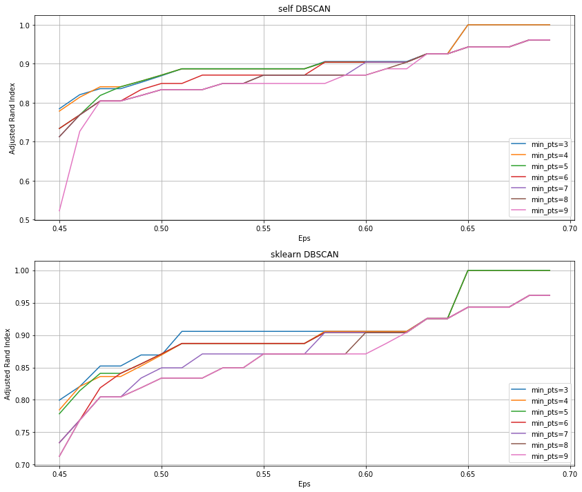

```python
min_pts_list = np.arange(3, 10)
eps_list = np.arange(0.45, 0.7, step=0.01)

fig, axes = plt.subplots(nrows=2, ncols=1, figsize=(14, 12))

for i in np.arange(2):
    axes[i].set_xlabel("Eps")
    axes[i].set_ylabel("Adjusted Rand Index")

axes[0].set_title('self DBSCAN')
axes[1].set_title('sklearn DBSCAN')

for min_pts in min_pts_list:
    self_ari = []
    sklearn_ari = []

    for eps in eps_list:
        self_model = DBScanClustering(eps=eps, min_pts=min_pts)
        self_pred = self_model.fit_predict(x_iris)

        sklearn_model = sc.DBSCAN(eps=eps, min_samples=min_pts)
        sklearn_pred = sklearn_model.fit_predict(x_iris)

        self_ari.append(smt.adjusted_rand_score(y_iris, self_pred))
        sklearn_ari.append(smt.adjusted_rand_score(y_iris, sklearn_pred))

    axes[0].plot(eps_list, self_ari, label='min_pts={}'.format(str(min_pts)))
    axes[1].plot(eps_list, sklearn_ari, label='min_pts={}'.format(str(min_pts)))

for i in np.arange(2):
    axes[i].legend(loc='lower right')
    axes[i].grid()
```

По этому графику видно, что для датасета Iris с любым значением числа ближайших соседей min_pts (3-9) можно выйти на очень приличное качество в районе 0.9 при eps > 0.57. Мы даже можем точно кластеризовать точки, взяв, например, eps = 0.65, min_pts = 4, и ни одна из точек не будет кластеризована как шум.

```python
model = DBScanClustering(eps=0.65, min_pts=4)
predicted_clusters = model.fit_predict(x_iris)
print("Adjusted Rand index for iris is: %.4f" % smt.adjusted_rand_score(y_iris, predicted_clusters))
```

```
Adjusted Rand index for iris is: 1.0000
```

Кроме того, наша реализация алгоритма и библиотечная кластеризуют с похожим качеством.

Далее необходимо кластеризовать с помощью реализованного алгоритма данные, используемые для демонстраций на предыдущих занятиях. Предлагается сделать сравнение с реализацией из sklearn.

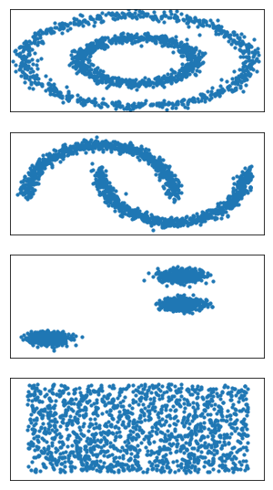

```python
# http://scikit-learn.org/stable/auto_examples/cluster/plot_cluster_comparison.html
%matplotlib inline

import numpy as np
import matplotlib.pyplot as plt

from sklearn import datasets
from sklearn.preprocessing import StandardScaler

np.random.seed(0)

n_samples = 1500
noisy_circles = datasets.make_circles(n_samples=n_samples, factor=.5,
                                      noise=.05)
noisy_moons = datasets.make_moons(n_samples=n_samples, noise=.05)
blobs = datasets.make_blobs(n_samples=n_samples, random_state=8)
no_structure = np.random.rand(n_samples, 2), None

plt.figure(figsize=(2 + 3, 9.5))

data = [noisy_circles, noisy_moons, blobs, no_structure]
for i_dataset, dataset in enumerate(data):
    X, y = dataset
    # normalize dataset for easier parameter selection
    X = StandardScaler().fit_transform(X)

    # plot
    plt.subplot(4, 1, i_dataset + 1)
    plt.scatter(X[:, 0], X[:, 1], s=10)
    plt.xlim(-2, 2)
    plt.ylim(-2, 2)
    plt.xticks(())
    plt.yticks(())

plt.show()
```

Сначала для всех 4-х случаев подберем параметры eps и min_pts с помощью эвристики, как это было сделано выше для ирисов.

```python
def plot_heuristics_calculation(data, title, eps_start, eps_stop):
    X, y = data
    X = StandardScaler().fit_transform(X)

    fix, ax = plt.subplots(figsize=(14, 6))

    for min_pts in np.arange(3, 10):
        mean_distances = DBScanClustering.mean_distance_to_nearest_neighbors(X, min_pts)
        mean_distances.sort()
        ax.plot(mean_distances, label='min_pts={}'.format(str(min_pts)))

    plt.title(title)
    plt.xlabel('Sorted distances over all pairs', fontsize=12)
    plt.ylabel('Mean distance over nearest neighbors', fontsize=12)
    plt.axhspan(eps_start, eps_stop, facecolor='blue', alpha=0.2)
    plt.grid()
    plt.legend()
    plt.show()
```

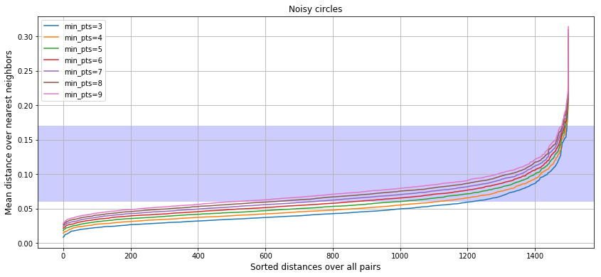

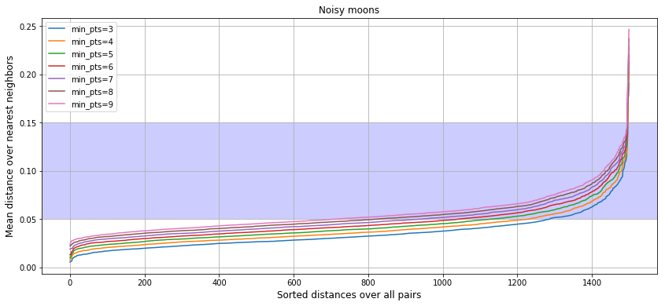

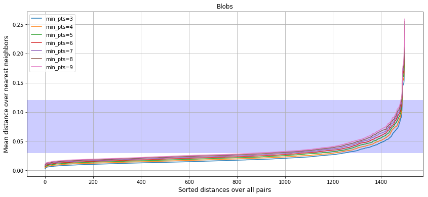

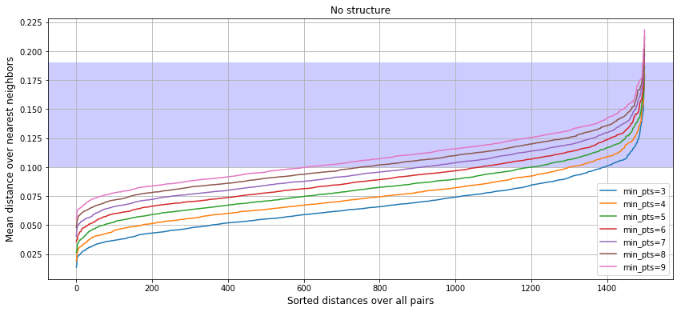

```python
datasets = [noisy_circles, noisy_moons, blobs, no_structure]
titles = ['Noisy circles', 'Noisy moons', 'Blobs', 'No structure']
eps_starts = [0.06, 0.05, 0.03, 0.1]
eps_stops = [0.17, 0.15, 0.12, 0.19]

for data, title, eps_start, eps_stop in zip(datasets, titles, eps_starts, eps_stops):
    plot_heuristics_calculation(data, title, eps_start, eps_stop)
```

Исходя из графиков выше, выберем следующие параметры:

```python
opt_min_pts = [4]*4
opt_eps = [0.15, 0.1, 0.1, 0.12]
```

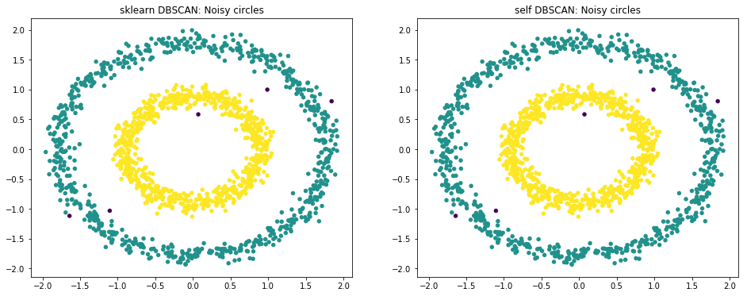

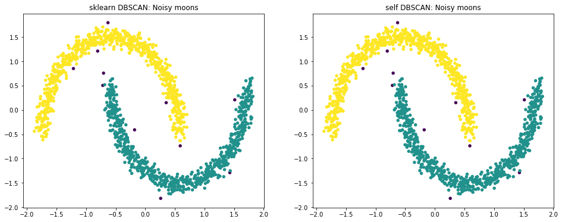

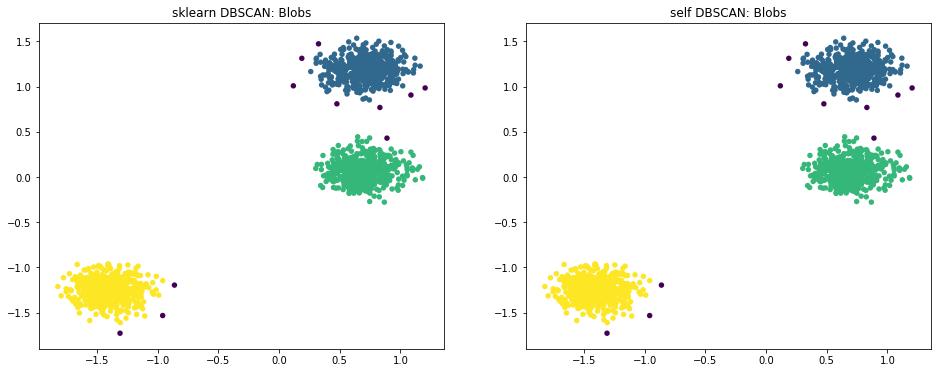

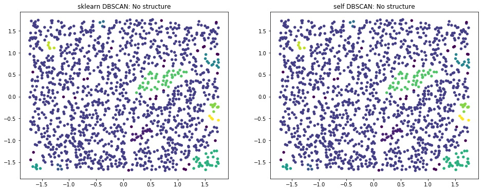

```python
for idx in np.arange(4):
    fig, axes = plt.subplots(nrows=1, ncols=2, figsize=(16, 6))

    data = datasets[idx]
    X, y = data
    X = StandardScaler().fit_transform(X)

    eps, min_pts = opt_min_pts[idx], opt_min_pts[idx]

    sklearn_model = sc.DBSCAN(eps=opt_eps[idx], min_samples=opt_min_pts[idx])
    sklearn_pred = sklearn_model.fit_predict(X)

    self_model = DBScanClustering(eps=opt_eps[idx], min_pts=opt_min_pts[idx])
    self_pred = self_model.fit_predict(X)

    axes[0].scatter(X[:, 0], X[:, 1], c=sklearn_pred, cmap=pl.cm.viridis, lw=0, s=30)
    axes[0].set_title('sklearn DBSCAN: {}'.format(titles[idx]))

    axes[1].scatter(X[:, 0], X[:, 1], c=sklearn_pred, cmap=pl.cm.viridis, lw=0, s=30)
    axes[1].set_title('self DBSCAN: {}'.format(titles[idx]))

    plt.show()
```

В первых трех случаях кластеры хорошо выделяются, несколько точек определяются как шумовые. Последний факт можно отнести как к плюсу, так и к минусу. Увеличив немного значение eps, эти шумовые точки "примкнут" к ближайшему кластеру.

С последним примером, в котором нет никакой структуры, наблюдаются сложности у алгоритма: он выявил несколько кластеров. Аналогично, при настройке eps алгоритм можно довести до отличного результата.